# Vitis_AI

# Overview

The Vitis™ AI development environment accelerates AI inference on Xilinx® hardware platforms, including both edge devices and Alveo™ accelerator cards. It consists of optimized IP cores, tools, libraries, models, and example designs. It is designed with high efficiency and ease of use in mind to unleash the full potential of AI acceleration on Xilinx FPGAs and on adaptive compute acceleration platforms (ACAPs). The Vitis AI development environment makes it easy for users without FPGA knowledge to develop deep-learning inference applications by abstracting the intricacies of the underlying FPGA and ACAP.

[figure not shown]

Vitis AI includes the following features:

- Supports mainstream frameworks and the latest models capable of diverse deep learning tasks.
- Provides a comprehensive set of pre-optimized models that are ready to deploy on Xilinx devices.
- Provides a powerful quantizer that supports model quantization, calibration, and fine tuning. For advanced users, Xilinx also offers an optional AI optimizer that can prune a model by up to 90% with a tolerable accuracy loss.
- Provides layer-by-layer analysis to help with bottlenecks.
- Offers unified high-level C++ and Python APIs for maximum portability from Edge to Cloud.
- Customizes efficient and scalable IP cores to meet your needs for many different applications from a throughput, latency, and power perspective.

The recommended development flow for Vitis™ AI is illustrated as the following figure. Vitis AI and Vitis IDE are needed for this flow which has three basic steps:

[figure not shown]

1. The Vitis AI toolchain in the host machine is used to build the model. It takes the pre-trained floating models as the input and runs them through the AI Optimizer (optional).
2. A custom hardware platform is built using the Vitis software platform based on the Vitis Target Platform. The generated hardware includes the DPU IP and other kernels. You can also use the Vivado® Design Suite to integrate the DPU and build the custom hardware to suit your need.
3. You can build executable software which runs on the built hardware. You can write your applications with C++ or Python which calls the Vitis AI Runtime and Vitis AI Library to load and run the compiled model files.

## Deep-Learning Processor Unit

The deep-learning processor unit (DPU) is a programmable engine optimized for deep neural networks. It is a group of parameterizable IP cores pre-implemented on the hardware with no place and route required. It is designed to accelerate the computing workloads of deep learning inference algorithms widely adopted in various computer vision applications, such as image/video classification, semantic segmentation, and object detection/tracking. The DPU is released with the Vitis AI specialized instruction set, thus facilitating the efficient implementation of deep learning networks.

A configuration file, `arch.json`, is generated during the Vitis flow. The `arch.json` file is used by the Vitis AI compiler for model compilation. Once the configuration of the DPU is modified, a new `arch.json` must be generated. The models must be regenerated using the new `arch.json` file.

Different fields of DPU name is used to indicate different features or purposes, and the naming scheme is shown in the following figure:

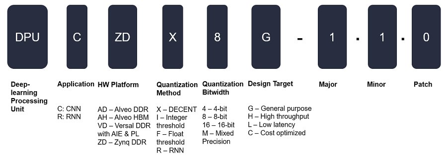

## Vitis AI Quantizer

By converting the 32-bit floating-point weights and activations to fixed-point like INT8, the Vitis AI quantizer can reduce the computing complexity without losing prediction accuracy. The fixed-point network model requires less memory bandwidth, thus providing faster speed and higher power efficiency than the floating-point model.

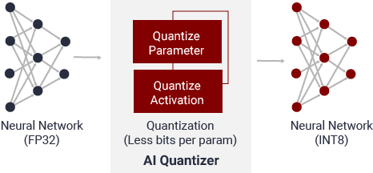

## Vitis AI Compiler

The Vitis AI compiler maps the AI model to a highly-efficient instruction set and dataflow model. It also performs sophisticated optimizations such as layer fusion, instruction scheduling, and reuses on-chip memory as much as possible.

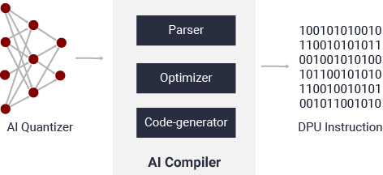

## Vitis AI Profiler

The Vitis AI profiler profiles and visualizes AI applications to find bottlenecks and allocates computing resources among different devices. It is easy to use and requires no code changes. It can trace function calls and run time, and also collect hardware information, including CPU, DPU, and memory utilization.

[figure not shown]

## Vitis AI Library

The Vitis AI Library is a set of high-level libraries and APIs built for efficient AI inference with DPUs. It fully supports the XRT and is built on Vitis AI runtime with Vitis runtime unified APIs.

The Vitis AI Library provides an easy-to-use and unified interface by encapsulating many efficient and high-quality neural networks. This simplifies the use of deep-learning neural networks, even for users without knowledge of deep-learning or FPGAs. The Vitis AI Library allows you to focus more on developing your applications rather than the underlying hardware.

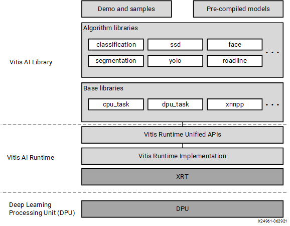

## Vitis AI Runtime

The Vitis AI runtime enables applications to use the unified high-level runtime API for both Cloud and Edge making Cloud-to-Edge deployments seamless and efficient.

Following are the features for the AI runtime API:

- Asynchronous submission of jobs to the accelerator
- Asynchronous collection of jobs from the accelerator
- C++ and Python implementations
- Support for multi-threading and multi-process execution

The framework of VART is shown in the following figure. For this Vitis AI release, VART is based on XRT. XIR is the Xilinx Intermediate Representation.

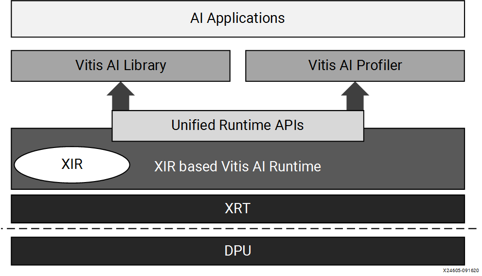

# Install

Make sure you have at least **100GB** of disk space for the disk partition running Docker.

## install Docker engine

[Reference](https://docs.docker.com/engine/install/ubuntu/)

Execute the folowing command in terminal

```
sudo apt-get update

sudo apt-get install ca-certificates curl gnupg lsb-release

sudo mkdir -p /etc/apt/keyrings

curl -fsSL https://download.docker.com/linux/ubuntu/gpg | sudo gpg --dearmor -o /etc/apt/keyrings/docker.gpg

echo "deb [arch=$(dpkg --print-architecture) signed-by=/etc/apt/keyrings/docker.gpg] https://download.docker.com/linux/ubuntu $(lsb_release -cs) stable" | sudo tee /etc/apt/sources.list.d/docker.list > /dev/null

sudo apt-get update

sudo apt-get install docker-ce docker-ce-cli containerd.io docker-compose-plugin
```

Verify docker engine:

```
sudo service docker start

sudo docker run hello-world
```

## manage docker as a non-root user

[Reference](https://docs.docker.com/engine/install/linux-postinstall/#manage-docker-as-a-non-root-user)

Add your linux user to the group *docker*

```
sudo groupadd docker

sudo usermod -aG docker $USER
```

After that, restart your virtual machine. Verify your setting:

```
docker run hello-world
```

## install git and get Vitis AI repository

```
sudo apt install git

git clone --recurse-submodules https://github.com/Xilinx/Vitis-AI

cd Vitis-AI
```

## install and run Vitis AI container

Two options are available for installing the containers with the Vitis AI tools and resources. Either one should work

### Using Pre-built Docker

This way is faster

Download the latest Vitis AI Docker with the following command. This container runs on CPU.

```
docker pull xilinx/vitis-ai-cpu:latest
```

To run the docker, use command:

```
./docker_run.sh xilinx/vitis-ai-cpu:latest
```

### Building Docker from Recipe

This takes about five hours to complete.

There are two types of docker recipes provided - CPU recipe and GPU recipe. If you have a compatible nVidia graphics card with CUDA support, you could use GPU recipe; otherwise you could use CPU recipe.

#### CPU Docker

Use below commands to build the CPU docker:

```
cd docker

./docker_build_cpu.sh
```

To run the CPU docker, use command:

```
../docker_run.sh xilinx/vitis-ai-cpu:latest
```

#### GPU Docker

Use below commands to build the GPU docker:

```
cd docker

./docker_build_gpu.sh
```

To run the GPU docker, use command:

```
../docker_run.sh xilinx/vitis-ai-gpu:latest
```

# ResNet 18 model training

[Reference](https://github.com/pytorch/examples/tree/main/imagenet)

After you start your Vitis AI container. Enter this command to start your pytorch environment and move to quantizer example folder:

```
conda activate vitis-ai-pytorch

cd src/Vitis-AI-Quantizer/vai_q_pytorch/
```

After you start your pytorch environment, you should see (vitis-ai-pytorch) at the start of your command line.

## prepare dataset

### download full ImageNet dataset

Go to [ImageNet](http://www.image-net.org) and register an account.

Then log in and get **ILSVRC2012** dataset -- both train dataset and validation dataset. This may take several hours because train set takes about 138GB space.

### extract full dataset

Move `ILSVRC2012_img_train.tar` to `<your Vitis AI repository>/src/Vitis-AI-Quantizer/vai_q_pytorch/example/imagenet_full/train` (create a folder and a subfolder for it). Execute the following command there to extract training set and remove compressed file:

```
tar -xvf ILSVRC2012_img_train.tar && rm -f ILSVRC2012_img_train.tar
```

At this stage `imagenet_full/train` will contain 1000 compressed `.tar` files, one for each category

Move `ILSVRC2012_img_val.tar` to `<your Vitis AI repository>/src/Vitis-AI-Quantizer/vai_q_pytorch/example/imagenet_full/val` (create another subfolder for it). Execute the following command there to extract validation .tar file, remove compressed file, create all class directories, and moves images into corresponding directories:

```
tar -xvf ILSVRC2012_img_val.tar && rm -f ILSVRC2012_img_val.tar

wget -qO- https://raw.githubusercontent.com/soumith/imagenetloader.torch/master/valprep.sh | bash
```

At this stage `imagenet_full/val` will contain 1000 folders (categories) with 50 `.JPEG` files each.

Create three folders to save the datasets you want to use: `<your Vitis AI repository>/src/Vitis-AI-Quantizer/vai_q_pytorch/example/imagenet`, `<your Vitis AI repository>/src/Vitis-AI-Quantizer/vai_q_pytorch/example/imagenet/train`, and , `<your Vitis AI repository>/src/Vitis-AI-Quantizer/vai_q_pytorch/example/imagenet/val`

### choose classification class

[This text file](https://github.com/Cadene/pretrained-models.pytorch/blob/master/data/imagenet_synsets.txt) represent the true meaning behind each class name. And you can find the list of all available ImageNet classes in `<your Vitis AI repository>/examples/VART/resnet50_pt/word_list.inc`. For example, you can see from the first line, folder `n02119789` represent class `kit fox, Vulpes macrotis`

Choose some classes you want to classify listed in `word_list.inc` file. Convert them into class name and find them in the `imagenet_full/val` folder. Check the content to see if it matches your expectation. If so, copy corresponding *training tar* and *val folder* into `imagenet/train` and `imagenet/val` respectively, and extract the training `.tar`. For example, if you want to train *balloon* class, which is encoded as `n02782093`. Then you should check `imagenet_full/val/n02782093` folder. Do the images match what you expected? If so, copy `imagenet_full/val/n02782093` to `imagenet/val`, move `imagenet_full/train/n02782093.tar` to `imagenet/train/n02782093` (create a new folder for it) and extract it inside.

After all desired class is chosen, you should have same folder name list in `imagenet/train` and `imagenet/val`

## training ResNet18 model

We use [this file](https://github.com/pytorch/examples/blob/main/imagenet/main.py) to train our model. save it in `<your Vitis AI repository>/src/Vitis-AI-Quantizer/vai_q_pytorch/example` folder

### modify main.py file

- replacce `if not torch.cuda.is_available() and not torch.backends.mps.is_available():` with `if not torch.cuda.is_available():`
- remove these parts in `main_worker` function definition:

```
    elif args.gpu is not None and torch.cuda.is_available():
        torch.cuda.set_device(args.gpu)
        model = model.cuda(args.gpu)
# remove this
#    elif torch.backends.mps.is_available():
#        device = torch.device("mps")
#        model = model.to(device)
...
    if torch.cuda.is_available():
        if args.gpu:
            device = torch.device('cuda:{}'.format(args.gpu))
        else:
            device = torch.device("cuda")
# and remove this
#    elif torch.backends.mps.is_available():
#        device = torch.device("mps")
```

- After `val_dataset` definition, add the following line to change `train_dataset.targets`, `train_dataset.samples`, `val_dataset.targets`, and `val_dataset.samples` according to their index in `word_list.inc` file. For example, you choose `balloon` and `eel` class, which is at `391th` and `418th` line in `word_list.inc` file (correspond to index 390 and 417 respectively). Add these lines:

```
val_dataset = datasets.ImageFolder(
    valdir,
    transforms.Compose([
        transforms.Resize(256),
        transforms.CenterCrop(224),
        transforms.ToTensor(),
        normalize,
    ]))

# add these lines
train_dataset.targets=torch.tensor(train_dataset.targets)
# first index points to balloon (390)
train_dataset.targets[train_dataset.targets == 0] = 390
# second index points to eel (417)
train_dataset.targets[train_dataset.targets == 1] = 417
train_dataset.samples = [(d, 390) if s == 0
                        else (d, 417) if s == 1
                        else (d, s) for d, s in train_dataset.samples]

val_dataset.targets=torch.tensor(val_dataset.targets)
val_dataset.targets[val_dataset.targets == 0] = 390
val_dataset.targets[val_dataset.targets == 1] = 417
val_dataset.samples = [(d, 390) if s == 0
                        else (d, 417) if s == 1
                        else (d, s) for d, s in val_dataset.samples]
```

- Remove this part in `validate` function definition

```
for i, (images, target) in enumerate(loader):
        i = base_progress + i
        if args.gpu is not None and torch.cuda.is_available():
            images = images.cuda(args.gpu, non_blocking=True)
# remove this part
#        if torch.backends.mps.is_available():
#            images = images.to('mps')
#            target = target.to('mps')
```

- Change `def save_checkpoint(state, is_best, filename='checkpoint.pth.tar'):` into `def save_checkpoint(state, is_best, filename='checkpoint.pth'):`
- Change `shutil.copyfile(filename, 'model_best.pth.tar')` into `shutil.copyfile(filename, 'model_best.pth')`
- Remove this part from `AverageMeter` class definition

```
def all_reduce(self):
    if torch.cuda.is_available():
        device = torch.device("cuda")
$ Remove this part
#        elif torch.backends.mps.is_available():
#            device = torch.device("mps")
```

### Start training

Use the following command to start training, or resume from checkpoint. After some time, you should get `checkpoint.pth` file (Save your latest epoch state) and `model_best.pth` file (Your best model so far)

```
# determine epoch number. default 90

python main.py --epoch epoch

# if you want to continue from checkpoint

python main.py --resume checkpoint.pth --epoch epoch

# if you want to evaluate accuracy

python main.py --resume model_best.pth -e
```

# Quantize your ResNet18 model

Make sure you activate your pytorch environment. You're in `<your Vitis AI repository>/src/Vitis-AI-Quantizer/vai_q_pytorch/example` folder with `model_best.pth` available.

Before running commands, let's introduce the log message in vai_q_pytorch. vai_q_pytorch log messages have special color and special keyword prefix "VAIQ_*". vai_q_pytorch log message types include "error", "warning" and "note". Pay attention to vai_q_pytorch log messages to check the flow status.

## modiffy resnet18_quant.py file

- change default `data_dir` and `model_dir` argument

```
parser.add_argument(
    '--data_dir',
# change this line
#    default="/path/to/imagenet/",
    default="/workspace/src/Vitis-AI-Quantizer/vai_q_pytorch/example/imagenet",
    help='Data set directory, when quant_mode=calib, it is for calibration, while quant_mode=test it is for evaluation')
parser.add_argument(
    '--model_dir',
# change this line
#    default="/path/to/trained_model/",
    default="/workspace/src/Vitis-AI-Quantizer/vai_q_pytorch/example",
    help='Trained model file path. Download pretrained model from the following url and put it in model_dir specified path: https://download.pytorch.org/models/resnet18-5c106cde.pth'
)
```

- Add another argument

```
parser.add_argument(
    '--model_name',
    default="model_best.pth",
    help='model name with format')
```

- After `dataset` definition, add the following line to change `dataset.targets` and `dataset.samples` according to their index in `word_list.inc` file. For example, you choose `bloon` and `eel` class, which is at `391th` and `418th` line in `word_list.inc` file (correspond to index 390 and 417 respectively). Add these lines (Note: there are two of them. Add both):

```
dataset = torchvision.datasets.ImageFolder(
    traindir,
    transforms.Compose([
        transforms.RandomResizedCrop(size),
        transforms.RandomHorizontalFlip(),
        transforms.ToTensor(),
        normalize,
    ]))

# add these lines
dataset.targets=torch.tensor(train_dataset.targets)
# first index points to balloon (390)
dataset.targets[dataset.targets == 0] = 390
# second index points to eel (417)
dataset.targets[dataset.targets == 1] = 417
dataset.samples = [(d, 390) if s == 0
                        else (d, 417) if s == 1
                        else (d, s) for d, s in dataset.samples]
```

- Replace `model.load_state_dict(torch.load(file_path))` with `model.load_state_dict(torch.load(file_path)['state_dict'])`
- Replace `model_name = 'resnet18'` with `model_name = args.model_name`
- Replace `file_path = os.path.join(args.model_dir, model_name + '.pth')` with `file_path = os.path.join(args.model_dir, model_name)`

## (Optional) Evaluate float model

In case you want to check accuracy again

```
python resnet18_quant.py --quant_mode float
```

## (Optional) Inspect float model

Vai_q_pytorch provides a function called inspector to help users diagnose neural network (NN) models under different device architectures. The inspector can predict target device assignments based on hardware constraints.The generated inspection report can be used to guide users to modify or optimize the NN model, greatly reducing the difficulty and time of deployment. It is recommended to inspect float models before quantization.

```
python resnet18_quant.py --quant_mode float --inspect
```

If the inspector runs successfully, three important files are usually generated under the output directory "./quantize_result".

```
inspect_{target}.txt: Target information and all the details of operations in float model.
inspect_{target}.svg: If image_format is not None. A visualization of inspection result is generated.
inspect_{target}.gv: If image_format is not None. Dot source code of inspetion result is generated.
```

## Quantize

Using whole validation data for calibration. Because we are in quantize calibration process, the displayed loss and accuracy are meaningless.

Run command with "--quant_mode calib" to quantize model.

```
python resnet18_quant.py --quant_mode calib
```

When doing calibration forward, we borrow float evaluation flow to minimize code change from float script. So there are loss and accuracy displayed in the end. They are meaningless, just skip them. Pay more attention to the colorful log messages with special keywords prefix "VAIQ_*".

Another important thing is to control iteration numbers during quantization and evaluation. Generally, 100-1000 images are enough for quantization and the whole validation set are required for evaluation. The iteration numbers can be controlled in the data loading part. In this case, argument "subset_len" controls how many images used for network forwarding. But if the float evaluation script doesn't have an argument with similar role, it is better to add one, otherwise it should be changed manually.

If this quantization command runs successfully, two important files will be generated under output directory “./quantize_result”.

```
ResNet.py: converted vai_q_pytorch format model,
Quant_info.json: quantization steps of tensors got. (Keep it for evaluation of quantized model)
```

## (Optional) Evaluate quantized model

To evaluate quantized model, run the following command:

```
python resnet18_quant.py --quant_mode test
```

When this command finishes, the displayed accuracy is the right accuracy for quantized model.

## Export xmodel and onnx

To export xmodel, `batch size 1` is must for compilation, and `subset_len=1` is to avoid redundant iteration. Run the following command:

```
python resnet18_quant.py --quant_mode test --subset_len 1 --batch_size 1 --deploy
```

Skip loss and accuracy displayed in log in this run. Xmodel file for Vitis AI compiler will be generated under output directory “./quantize_result”. It will be further used to deploy this model to FPGA.

```
ResNet_int.xmodel: deployed XIR format model
ResNet_int.onnx:   deployed onnx format model
```

# compile your Quantized ResNet18 xmodel

The XIR-based compiler takes the quantized Caffe1, TensorFlow, TensorFlow2.x or PyTorch model as the input. First, it transforms the input models into the XIR format as the foundation for the following processes. Most of the variations among different frameworks are eliminated and transferred to a unified representation in XIR. Then, it applies various optimizations to the graph and breaks up the graph into several subgraphs on the basis of whether the operation can be executed on the DPU. Architecture-aware optimizations are applied for each subgraph, as required. For the DPU subgraph, the compiler generates the instruction stream and attaches to it. Finally, the optimized graph with the necessary information and instructions for VART is serialized into a compiled xmodel file. You can find the `arch.json` files for some platforms in `/opt/vitis_ai/compiler/arch.`

For PyTorch, the quantizer NNDCT outputs the quantized model in the XIR format directly. Use vai_c_xir to compile it.

```
vai_c_xir -x /PATH/TO/quantized.xmodel -a /PATH/TO/arch.json -o /OUTPUTPATH -n netname
```

# Vision Transformer

## Introduction to the Vision Transformer (ViT)

[Reference](https://arxiv.org/abs/1706.03762)

Vision Transformer's predecessor, Transformer. Its architecture has revolutionized the use of attention, without relying on recurrence and convolutions as earlier attention models had previously done. Transformer is applied to the specific problem of natural language processing (NLP).

Inspired by its success in NLP, **Dosovitskiy et al. (2021)** sought to apply the standard Transformer architecture to images, as we shall see shortly. Their target application at the time was image classification.

The input to the encoder is a sequence of embedded image patches (including a learnable class embedding prepended to the sequence), which is also augmented with positional information. A classification head attached to the output of the encoder receives the value of the learnable class embedding, to generate a classification output based on its state. All of this is illustrated by the figure below:

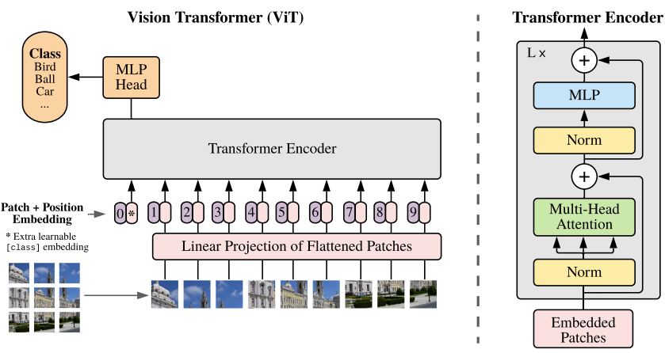

## training Vision Transformer

[Reference](https://github.com/pytorch/examples/tree/main/imagenet)

If you trained resnet18 before, you only need to change the way you import pretrained model as well as the execute command. You may skip the other steps.

After you start your Vitis AI container. Enter this command to start your pytorch environment and move to quantizer example folder:

```
conda activate vitis-ai-pytorch

cd src/Vitis-AI-Quantizer/vai_q_pytorch/
```

After you start your pytorch environment, you should see (vitis-ai-pytorch) at the start of your command line.

### prepare dataset

#### download full ImageNet dataset

Go to [ImageNet](http://www.image-net.org) and register an account.

Then log in and get **ILSVRC2012** dataset -- both train dataset and validation dataset. This may take several hours because train set takes about 138GB space.

#### extract full dataset

Move `ILSVRC2012_img_train.tar` to `<your Vitis AI repository>/src/Vitis-AI-Quantizer/vai_q_pytorch/example/imagenet_full/train` (create a folder and a subfolder for it). Execute the following command there to extract training set and remove compressed file:

```
tar -xvf ILSVRC2012_img_train.tar && rm -f ILSVRC2012_img_train.tar
```

At this stage `imagenet_full/train` will contain 1000 compressed `.tar` files, one for each category

Move `ILSVRC2012_img_val.tar` to `<your Vitis AI repository>/src/Vitis-AI-Quantizer/vai_q_pytorch/example/imagenet_full/val` (create another subfolder for it). Execute the following command there to extract validation .tar file, remove compressed file, create all class directories, and moves images into corresponding directories:

```
tar -xvf ILSVRC2012_img_val.tar && rm -f ILSVRC2012_img_val.tar

wget -qO- https://raw.githubusercontent.com/soumith/imagenetloader.torch/master/valprep.sh | bash
```

At this stage `imagenet_full/val` will contain 1000 folders (categories) with 50 `.JPEG` files each.

Create three folders to save the datasets you want to use: `<your Vitis AI repository>/src/Vitis-AI-Quantizer/vai_q_pytorch/example/imagenet`, `<your Vitis AI repository>/src/Vitis-AI-Quantizer/vai_q_pytorch/example/imagenet/train`, and , `<your Vitis AI repository>/src/Vitis-AI-Quantizer/vai_q_pytorch/example/imagenet/val`

#### choose classification class

[This text file](https://github.com/Cadene/pretrained-models.pytorch/blob/master/data/imagenet_synsets.txt) represent the true meaning behind each class name. And you can find the list of all available ImageNet classes in `<your Vitis AI repository>/examples/VART/resnet50_pt/word_list.inc`. For example, you can see from the first line, folder `n02119789` represent class `kit fox, Vulpes macrotis`

Choose some classes you want to classify listed in `word_list.inc` file. Convert them into class name and find them in the `imagenet_full/val` folder. Check the content to see if it matches your expectation. If so, copy corresponding *training tar* and *val folder* into `imagenet/train` and `imagenet/val` respectively, and extract the training `.tar`. For example, if you want to train *balloon* class, which is encoded as `n02782093`. Then you should check `imagenet_full/val/n02782093` folder. Do the images match what you expected? If so, copy `imagenet_full/val/n02782093` to `imagenet/val`, move `imagenet_full/train/n02782093.tar` to `imagenet/train/n02782093` (create a new folder for it) and extract it inside.

After all desired class is chosen, you should have same folder name list in `imagenet/train` and `imagenet/val`

We use [this file](https://github.com/pytorch/examples/blob/main/imagenet/main.py) to train our model. save it in `<your Vitis AI repository>/src/Vitis-AI-Quantizer/vai_q_pytorch/example` folder

#### modify main.py file

- We use pretrained ViT model. Change the pretrained parameter

```
# create model
    if args.pretrained:
        print("=> using pre-trained model '{}'".format(args.arch))
        # remove this line
        # model = models.__dict__[args.arch](pretrained=True)
        # add this line
        model = torch.hub.load('rwightman/pytorch-image-models:0.6.x', 'vit_small_patch16_224', pretrained=True)
    else:
        print("=> creating model '{}'".format(args.arch))
        model = models.__dict__[args.arch]()
```

- replacce `if not torch.cuda.is_available() and not torch.backends.mps.is_available():` with `if not torch.cuda.is_available():`
- remove these parts in `main_worker` function definition:

```
    elif args.gpu is not None and torch.cuda.is_available():
        torch.cuda.set_device(args.gpu)
        model = model.cuda(args.gpu)
# remove this
#    elif torch.backends.mps.is_available():
#        device = torch.device("mps")
#        model = model.to(device)
...
    if torch.cuda.is_available():
        if args.gpu:
            device = torch.device('cuda:{}'.format(args.gpu))
        else:
            device = torch.device("cuda")
# and remove this
#    elif torch.backends.mps.is_available():
#        device = torch.device("mps")
```

- After `val_dataset` definition, add the following line to change `train_dataset.targets`, `train_dataset.samples`, `val_dataset.targets`, and `val_dataset.samples` according to their index in `word_list.inc` file. For example, you choose `balloon` and `eel` class, which is at `391th` and `418th` line in `word_list.inc` file (correspond to index 390 and 417 respectively). Add these lines:

```
val_dataset = datasets.ImageFolder(
    valdir,
    transforms.Compose([
        transforms.Resize(256),
        transforms.CenterCrop(224),
        transforms.ToTensor(),
        normalize,
    ]))

# add these lines
train_dataset.targets=torch.tensor(train_dataset.targets)
# first index points to balloon (390)
train_dataset.targets[train_dataset.targets == 0] = 390
# second index points to eel (417)
train_dataset.targets[train_dataset.targets == 1] = 417
train_dataset.samples = [(d, 390) if s == 0
                        else (d, 417) if s == 1
                        else (d, s) for d, s in train_dataset.samples]

val_dataset.targets=torch.tensor(val_dataset.targets)
val_dataset.targets[val_dataset.targets == 0] = 390
val_dataset.targets[val_dataset.targets == 1] = 417
val_dataset.samples = [(d, 390) if s == 0
                        else (d, 417) if s == 1
                        else (d, s) for d, s in val_dataset.samples]
```

- Remove this part in `validate` function definition

```
for i, (images, target) in enumerate(loader):
        i = base_progress + i
        if args.gpu is not None and torch.cuda.is_available():
            images = images.cuda(args.gpu, non_blocking=True)
# remove this part
#        if torch.backends.mps.is_available():
#            images = images.to('mps')
#            target = target.to('mps')
```

- Change `def save_checkpoint(state, is_best, filename='checkpoint.pth.tar'):` into `def save_checkpoint(state, is_best, filename='checkpoint.pth'):`
- Change `shutil.copyfile(filename, 'model_best.pth.tar')` into `shutil.copyfile(filename, 'model_best.pth')`
- Remove this part from `AverageMeter` class definition

```
def all_reduce(self):
    if torch.cuda.is_available():
        device = torch.device("cuda")
$ Remove this part
#        elif torch.backends.mps.is_available():
#            device = torch.device("mps")
```

### Start training

Use the following command to start training. After some time, you should get `checkpoint.pth` file (Save your latest epoch state) and `model_best.pth` file (Your best model so far)

```
# determine epoch number. default 90

python main.py --pretrained --epoch epoch

# if you want to evaluate accuracy

python main.py --pretrained -e
```